# NZ GREEN Grid Household Electricity Demand Data

EECA Data Analysis (Part B) GXP Data Report v0.5

Ben Anderson

Last run at: 2019-10-20 21:38:27 (Pacific/Auckland)

# 1 About

## 1.1 Citation

If you wish to use any of the material from this report please cite as:

- Ben Anderson (2019) *NZ GREEN Grid Household Electricity Demand Data: EECA Data Analysis (Part B) GXP Data Report v0.5*, [Centre for Sustainability](http://www.otago.ac.nz/centre-sustainability/), University of Otago: Dunedin.

This work is (c) 2019 the authors. Usage right are specified in the License section (1.3).

## 1.2 Report circulation

- Public – this report is intended for publication following EECA approval.

## 1.3 License

This work is made available under the Creative Commons [Attribution-ShareAlike 4.0 International (CC BY-SA 4.0) License](https://creativecommons.org/licenses/by-sa/4.0/).

This means you are free to:

- *Share* — copy and redistribute the material in any medium or format
- *Adapt* — remix, transform, and build upon the material for any purpose, even commercially.

Under the following terms:

- *Attribution* — You must give appropriate credit, provide a link to the license, and indicate if changes were made. You may do so in any reasonable manner, but not in any way that suggests the licensor endorses you or your use.
- *ShareAlike* — If you remix, transform, or build upon the material, you must distribute your contributions under the same license as the original.
- *No additional restrictions* — You may not apply legal terms or technological measures that legally restrict others from doing anything the license permits.

**Notices:**

- You do not have to comply with the license for elements of the material in the public domain or where your use is permitted by an applicable exception or limitation.
- No warranties are given. The license may not give you all of the permissions necessary for your intended use. For example, other rights such as publicity, privacy, or moral rights may limit how you use the material.

For the avoidance of doubt and explanation of terms please refer to the full [license notice](https://creativecommons.org/licenses/by-sa/4.0/) and [legal code](https://creativecommons.org/licenses/by-sa/4.0/legalcode).

## 1.4 History

You may not be reading the most recent version of this report. Please check:

- the github [R code repository](https://cfsotago.github.io/GREENGridEECA/);
- our [issues list](https://github.com/CfSOtago/GREENGridEECA/issues) for any unfixed problems;
- our [project documentation site](https://cfsotago.github.io/GREENGridEECA/) and specifically;
- this [report’s edit history](https://github.com/CfSOtago/GREENGridEECA/commits/master/reports/partA_dataProcessing)

## 1.5 Support

This work was supported by:

- The New Zealand Energy Efficiency and Conservation Authority ([EECA](https://www.eeca.govt.nz/))

# 2 Introduction

This report uses the Electricity Authority EMI [grid export database](https://www.emi.ea.govt.nz/Wholesale/Datasets/Metered_data/Grid_export) to:

- explore the GXP data
- identify system peak half-hours for the regions of Taranaki and Hawke’s Bay in 2015 for use in the Part B data analysis

This report describes the results of this work and directs the reader to relevant R code where necessary.

All code used to create this report is available from:

- https://github.com/CfSOtago/GREENGridEECA

The archived and most recent version of the report is available from:

- https://cfsotago.github.io/GREENGridEECA/

# 3 Data

# 4 Grid exit point (GXP)

A grid exit point (GXP) is defined in Part 1 of the Code and means any point of connection on the grid at which electricity predominantly flows out of the grid or is determined as being such by the Authority following an application in accordance with clause 13.28. Any such point of connection may, at any given time, be a GXP or a GIP, but may not be both at the same time."

For (very little) further information see the [EMI glossary](https://www.emi.ea.govt.nz/Glossary#G).

```
## Matched regions:
```

```
##
## Hawke's bay    Taranaki        <NA>
##      107310      286160     8296435
```

Start date: 2013-01-01

End date: 2015-12-31

Table 4.1: Number of observations per month and year in data used for this report

| 2013 | 2015 |
| --- | --- |
| 360096 | 366048 |
| 325248 | 329760 |
| 362448 | 361584 |
| 355927 | 340076 |
| 365424 | 352128 |
| 354240 | 341280 |
| 369024 | 352656 |
| 369024 | 353664 |
| 357564 | 341768 |
| 370512 | 354144 |
| 358560 | 343584 |
| 370512 | 355824 |

# 5 Explore GXP data

Figure 5.1 shows the mean total network electricity export by season and year for all regions combined as a data sense-check.

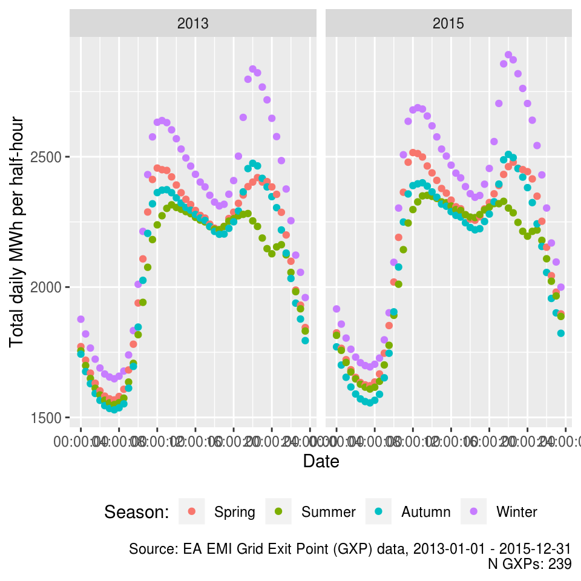

Figure 5.1: Mean total kWh per half hour by season

Next we use the GXP data to identify local (regional) system peak load half-hours for Hawke’s Bay and Taranaki as this matches the [GREEN Grid household sample location](https://cfsotago.github.io/GREENGridData/overviewReport_v1.0.html). Selected GXPs for the regions we are interested in:

Table 5.1: Summary of MWh per half hour by year, region, GXP nodes selected and network codes

| regionName | node | NWK_Code | year | nHalfHours | meanMWh |
| --- | --- | --- | --- | --- | --- |
| Hawke’s bay | FHL0331 | HAWK | 2013 | 17517 | 14.04 |
| Hawke’s bay | FHL0331 | HAWK | 2015 | 17517 | 14.90 |
| Hawke’s bay | RDF0331 | HAWK | 2013 | 17517 | 16.16 |
| Hawke’s bay | RDF0331 | HAWK | 2015 | 17517 | 15.67 |
| Hawke’s bay | WTU0331 | HAWK | 2013 | 17517 | 24.22 |
| Hawke’s bay | WTU0331 | HAWK | 2015 | 17517 | 24.18 |
| Taranaki | CST0331 | POCO | 2013 | 17517 | 14.68 |
| Taranaki | CST0331 | POCO | 2015 | 17517 | 15.64 |
| Taranaki | HUI0331 | POCO | 2013 | 17517 | 5.36 |
| Taranaki | HUI0331 | POCO | 2015 | 17517 | 6.67 |
| Taranaki | HWA0331 | POCO | 2013 | 17517 | 8.80 |
| Taranaki | HWA0331 | POCO | 2015 | 17517 | 9.64 |
| Taranaki | NPL0331 | CTCT | 2013 | 8689 | 0.15 |
| Taranaki | NPL0331 | POCO | 2013 | 17517 | 4.96 |
| Taranaki | NPL0331 | POCO | 2015 | 17517 | 4.80 |
| Taranaki | NPL0331 | PTNP | 2013 | 8828 | 0.11 |
| Taranaki | NPL0331 | PTNP | 2015 | 17517 | 0.04 |
| Taranaki | OPK0331 | POCO | 2013 | 17517 | 2.70 |
| Taranaki | OPK0331 | POCO | 2015 | 17517 | 2.83 |
| Taranaki | SFD0331 | POCO | 2013 | 17517 | 7.19 |
| Taranaki | SFD0331 | POCO | 2015 | 17517 | 7.43 |
| Taranaki | WGN0331 | POCO | 2013 | 17517 | 7.99 |
| Taranaki | WGN0331 | POCO | 2015 | 17517 | 7.80 |

Figure 5.2 shows the same results as above but only for the regions of interest: Taranaki and Hawke’s Bay.

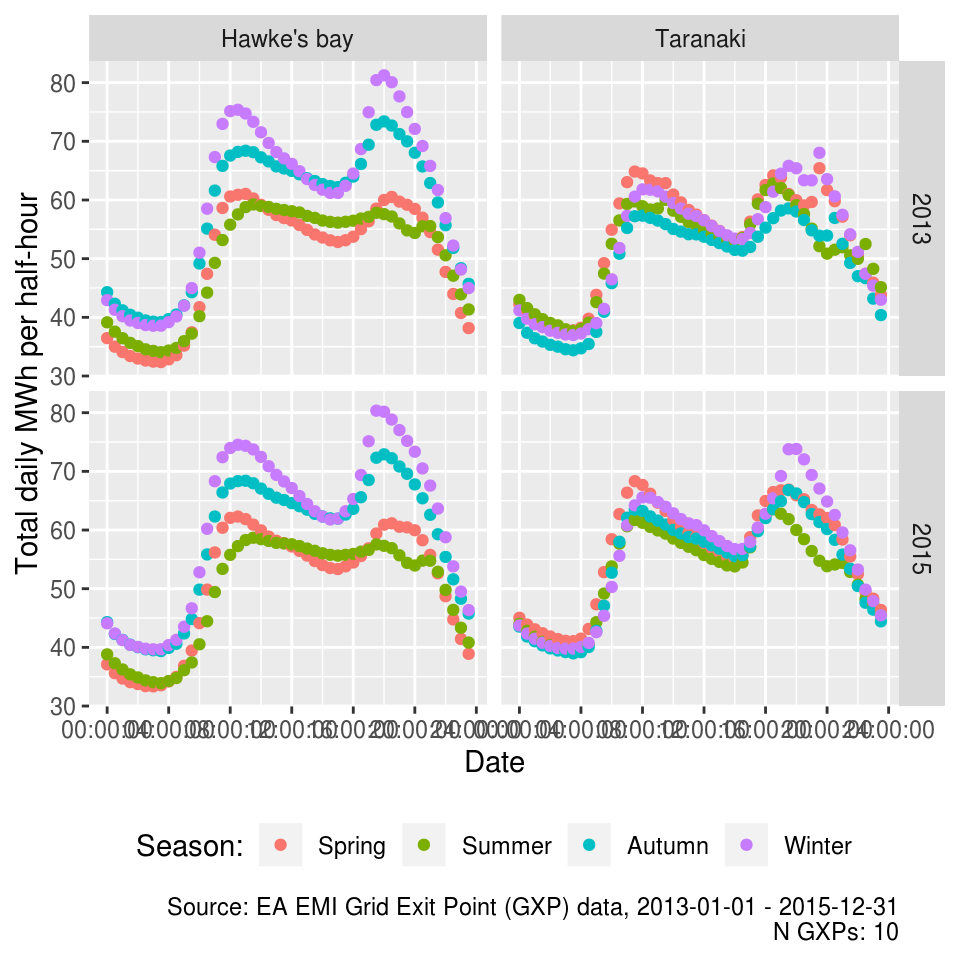

Figure 5.2: Mean total kWh per half hour by season and region

# 6 Top 100 ‘peaks’ in 2015

Extract data for winter (Jun - August) 2015 as per original EECA file. Aggregate to region level and select the top 100 half hours for each region.

[output not shown]

[output cut: 33 more lines]

```
##  Sun:148032   Length:1047600    Length:1047600    Length:1047600
##  Mon:159408   Class1:hms        Class1:hms        Class :character
##  Tue:148032   Class2:difftime   Class2:difftime   Mode  :character
##  Wed:148032   Mode  :numeric    Mode  :numeric
##  Thu:148032
##  Fri:148032
##  Sat:148032
##   regionName                peakPeriod          year         season
##  Length:1047600     Early morning:305550   Min.   :2015   Spring:      0
##  Class :character   Morning peak : 87300   1st Qu.:2015   Summer:      0
##  Mode  :character   Day time     :349200   Median :2015   Autumn:      0
##                     Evening peak :174600   Mean   :2015   Winter:1047600
##                     Late evening :130950   3rd Qu.:2015
##                                            Max.   :2015
##
```

```
## Empty data.table (0 rows and 4 cols): node,Time_Period,rDateTime,kWh
```

```
##      node           Time_Period          rDateTime       kWh
##  Length:0           Length:0           Min.   :NA   Min.   : NA
##  Class :character   Class :character   1st Qu.:NA   1st Qu.: NA
##  Mode  :character   Mode  :character   Median :NA   Median : NA
##                                        Mean   :NA   Mean   :NaN
##                                        3rd Qu.:NA   3rd Qu.: NA
##                                        Max.   :NA   Max.   : NA
```

```
##
##           Hawke's bay Taranaki <NA>
##   CST0331           0     4416    0
##   FHL0331        4416        0    0
##   HUI0331           0     4416    0
##   HWA0331           0     4416    0
##   NPL0331           0     8832    0
##   OPK0331           0     4416    0
##   RDF0331        4416        0    0
##   SFD0331           0     4416    0
##   WGN0331           0     4416    0
##   WTU0331        4416        0    0
##   <NA>              0        0    0
```

```
##
##           HAWK POCO PTNP <NA>
##   CST0331    0 4416    0    0
##   FHL0331 4416    0    0    0
##   HUI0331    0 4416    0    0
##   HWA0331    0 4416    0    0
##   NPL0331    0 4416 4416    0
##   OPK0331    0 4416    0    0
##   RDF0331 4416    0    0    0
##   SFD0331    0 4416    0    0
##   WGN0331    0 4416    0    0
##   WTU0331 4416    0    0    0
##   <NA>       0    0    0    0
```

[output not shown]

[output cut: 25 more lines]

```
##         X       0    48576 48576 1768252.09 1e+05    1679853 1688836
##         Y       0    48576 48576 5638053    33117.13 5576956 5609948
##      year       0    48576 48576    2015        0       2015    2015
##      p50     p75    p100     hist
##     8321   15766   45281 ▇▇▃▃▁▁▁▁
##        7       8       8 ▇▁▁▇▁▁▁▇
##  1712536 1923083 1933253 ▇▃▁▂▁▁▁▅
##  5639246 5676251 5677676 ▂▁▃▃▂▂▁▇
##     2015    2015    2015 ▁▁▁▇▁▁▁▁
##
## ── Variable type:POSIXct ─────────────────────────────────────────────────────────────────────────────────────────────────────────────────────────────
##   variable missing complete     n        min        max     median
##  rDateTime       0    48576 48576 2015-06-01 2015-08-31 2015-07-16
##  n_unique
##      4416
```

```
##
##  HAWK  POCO  PTNP
## 13248 30912  4416
```

```
##
##     X
## 48576
```

```
##
##    GD    GN
##  4416 44160
```

```
##
##  TPNZ
## 48576
```

[output not shown]

[output cut: 33 more lines]

```
##  Sun:6864    Length:48576      Length:48576      Length:48576
##  Mon:7392    Class1:hms        Class1:hms        Class :character
##  Tue:6864    Class2:difftime   Class2:difftime   Mode  :character
##  Wed:6864    Mode  :numeric    Mode  :numeric
##  Thu:6864
##  Fri:6864
##  Sat:6864
##   regionName                peakPeriod         year         season
##  Length:48576       Early morning:14168   Min.   :2015   Spring:    0
##  Class :character   Morning peak : 4048   1st Qu.:2015   Summer:    0
##  Mode  :character   Day time     :16192   Median :2015   Autumn:    0
##                     Evening peak : 8096   Mean   :2015   Winter:48576
##                     Late evening : 6072   3rd Qu.:2015
##                                           Max.   :2015
##
```

```
## Empty data.table (0 rows and 38 cols): node,region,region name,X,Y,OBJECTID...
```

```
##     region           regionName        Time_Period            hours
##  Length:8832        Length:8832        Length:8832        Min.   : 0.00
##  Class :character   Class :character   Class :character   1st Qu.: 5.75
##  Mode  :character   Mode  :character   Mode  :character   Median :11.50
##                                                           Mean   :11.50
##                                                           3rd Qu.:17.25
##                                                           Max.   :23.00
##
##    rDateTime                     weekdays                 peakPeriod
##  Min.   :2015-06-01 00:00:00   Length:8832        Early morning:2576
##  1st Qu.:2015-06-23 23:52:30   Class :character   Morning peak : 736
##  Median :2015-07-16 23:45:00   Mode  :character   Day time     :2944
##  Mean   :2015-07-16 23:45:00                      Evening peak :1472
##  3rd Qu.:2015-08-08 23:37:30                      Late evening :1104
##  Max.   :2015-08-31 23:30:00
##
##      sumkWh           nObs        nRegions   nLocations   nNetworks
##  Min.   :31040   Min.   :3.0   Min.   :1   Min.   :3    Min.   :1.0
##  1st Qu.:46001   1st Qu.:3.0   1st Qu.:1   1st Qu.:3    1st Qu.:1.0
##  Median :59527   Median :5.5   Median :1   Median :5    Median :1.5
##  Mean   :58533   Mean   :5.5   Mean   :1   Mean   :5    Mean   :1.5
##  3rd Qu.:68452   3rd Qu.:8.0   3rd Qu.:1   3rd Qu.:7    3rd Qu.:2.0
##  Max.   :95432   Max.   :8.0   Max.   :1   Max.   :7    Max.   :2.0
##
##    nGenTypes       month          hms
##  Min.   :1.0   Jul    :2976   Length:8832
##  1st Qu.:1.0   Aug    :2976   Class1:hms
##  Median :1.5   Jun    :2880   Class2:difftime
##  Mean   :1.5   Jan    :   0   Mode  :numeric
##  3rd Qu.:2.0   Feb    :   0
##  Max.   :2.0   Mar    :   0
##                (Other):   0
```

```
##
##                 Jan Feb Mar Apr May Jun Jul Aug Sep Oct Nov Dec
##   Early morning   0   0   0   0   0   0   0   0   0   0   0   0
##   Morning peak    0   0   0   0   0   0   0  25   0   0   0   0
##   Day time        0   0   0   0   0   0   0   5   0   0   0   0
##   Evening peak    0   0   0   0   0  13  13  44   0   0   0   0
##   Late evening    0   0   0   0   0   0   0   0   0   0   0   0
```

```
##     regionName hours Time_Period nPeaks
##  1:   Taranaki     7        TP15      3
##  2:   Taranaki     7        TP16     11
##  3:   Taranaki     8        TP17      9
##  4:   Taranaki     8        TP18      2
##  5:   Taranaki    16        TP34      5
##  6:   Taranaki    17        TP35      3
##  7:   Taranaki    17        TP36     24
##  8:   Taranaki    18        TP37     28
##  9:   Taranaki    18        TP38     12
## 10:   Taranaki    19        TP39      2
## 11:   Taranaki    19        TP40      1
```

```
##
##                 Jan Feb Mar Apr May Jun Jul Aug Sep Oct Nov Dec
##   Early morning   0   0   0   0   0   0   0   0   0   0   0   0
##   Morning peak    0   0   0   0   0  10   5   1   0   0   0   0
##   Day time        0   0   0   0   0   8  24   1   0   0   0   0
##   Evening peak    0   0   0   0   0  32  17   0   0   0   0   0
##   Late evening    0   0   0   0   0   0   2   0   0   0   0   0
```

```
##      regionName hours Time_Period nPeaks
##  1: Hawke's bay     7        TP16      6
##  2: Hawke's bay     8        TP17      5
##  3: Hawke's bay     8        TP18      5
##  4: Hawke's bay     9        TP19      4
##  5: Hawke's bay     9        TP20      5
##  6: Hawke's bay    10        TP21      3
##  7: Hawke's bay    10        TP22      6
##  8: Hawke's bay    11        TP23      3
##  9: Hawke's bay    11        TP24      2
## 10: Hawke's bay    12        TP25      3
## 11: Hawke's bay    12        TP26      2
## 12: Hawke's bay    13        TP27      1
## 13: Hawke's bay    16        TP33      1
## 14: Hawke's bay    16        TP34      3
## 15: Hawke's bay    17        TP35      6
## 16: Hawke's bay    17        TP36     12
## 17: Hawke's bay    18        TP37      9
## 18: Hawke's bay    18        TP38      5
## 19: Hawke's bay    19        TP39      6
## 20: Hawke's bay    19        TP40      5
## 21: Hawke's bay    20        TP41      4
## 22: Hawke's bay    20        TP42      2
## 23: Hawke's bay    21        TP43      1
## 24: Hawke's bay    21        TP44      1
##      regionName hours Time_Period nPeaks
```

## 6.1 Hawke’s Bay

Figure 6.1 shows the total network electricity export in this region as a data sense-check.

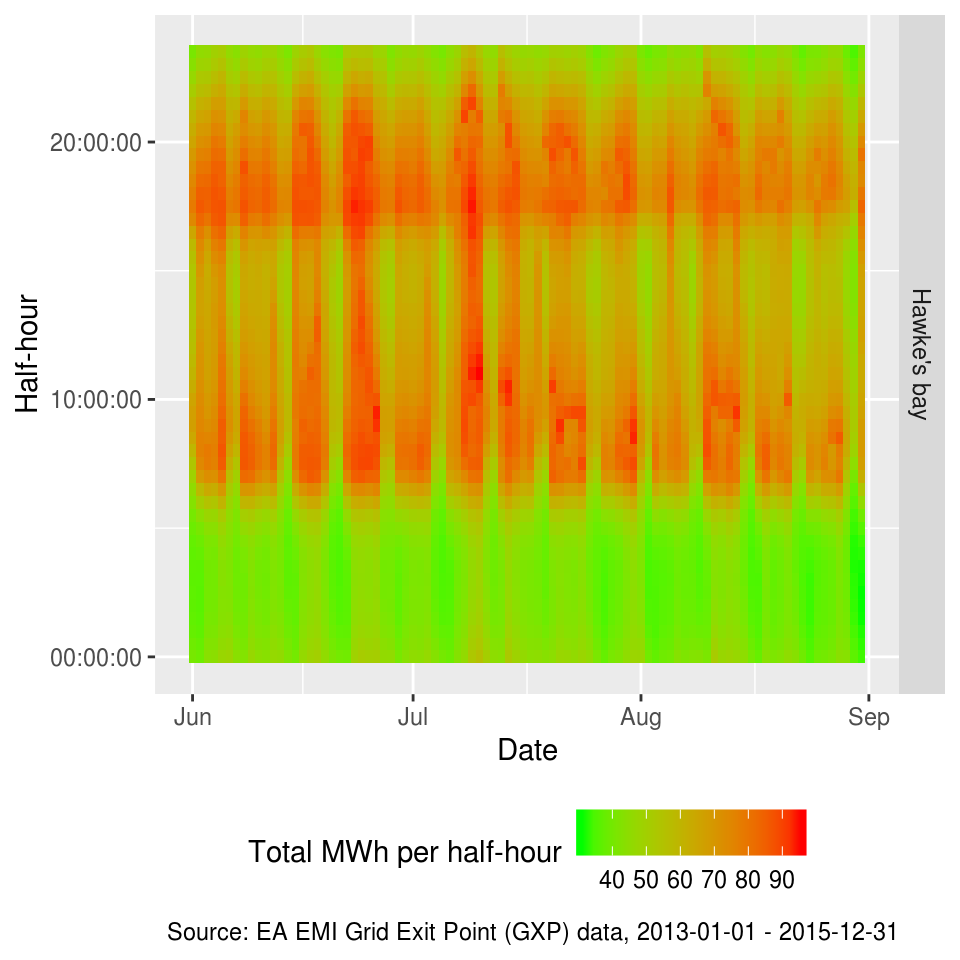

Figure 6.1: Hawke’s Bay: Total MWh per half hour

Table 6.1 shows the top 10 peak demand periods.

Table 6.1: Top 10 of top 100 Hawke’s Bay peak demand half-hours

| regionName | Time_Period | hms | rDateTime | weekdays | peakPeriod | sumkWh |
| --- | --- | --- | --- | --- | --- | --- |
| Hawke’s bay | TP23 | 11:00:00 | 2015-07-10 11:00:00 | Weekdays | Day time | 95432 |
| Hawke’s bay | TP36 | 17:30:00 | 2015-07-09 17:30:00 | Weekdays | Evening peak | 94725 |
| Hawke’s bay | TP24 | 11:30:00 | 2015-07-10 11:30:00 | Weekdays | Day time | 94214 |
| Hawke’s bay | TP20 | 09:30:00 | 2015-06-26 09:30:00 | Weekdays | Day time | 94115 |
| Hawke’s bay | TP36 | 17:30:00 | 2015-06-23 17:30:00 | Weekdays | Evening peak | 94018 |
| Hawke’s bay | TP23 | 11:00:00 | 2015-07-09 11:00:00 | Weekdays | Day time | 93898 |
| Hawke’s bay | TP22 | 10:30:00 | 2015-07-14 10:30:00 | Weekdays | Day time | 93834 |
| Hawke’s bay | TP18 | 08:30:00 | 2015-07-31 08:30:00 | Weekdays | Morning peak | 93627 |
| Hawke’s bay | TP37 | 18:00:00 | 2015-07-09 18:00:00 | Weekdays | Evening peak | 93603 |
| Hawke’s bay | TP19 | 09:00:00 | 2015-07-21 09:00:00 | Weekdays | Day time | 92724 |

Table 6.2 shows when the top 100 peak demand periods occured.

Table 6.2: Hawke’s Bay peak demand half-hours

| Time_Period | hms | weekdays | peakPeriod | nHalfHours |
| --- | --- | --- | --- | --- |
| TP36 | 17:30:00 | Weekdays | Evening peak | 12 |
| TP37 | 18:00:00 | Weekdays | Evening peak | 9 |
| TP16 | 07:30:00 | Weekdays | Morning peak | 6 |
| TP22 | 10:30:00 | Weekdays | Day time | 6 |
| TP35 | 17:00:00 | Weekdays | Evening peak | 6 |
| TP39 | 19:00:00 | Weekdays | Evening peak | 6 |
| TP17 | 08:00:00 | Weekdays | Morning peak | 5 |
| TP18 | 08:30:00 | Weekdays | Morning peak | 5 |
| TP20 | 09:30:00 | Weekdays | Day time | 5 |
| TP38 | 18:30:00 | Weekdays | Evening peak | 5 |
| TP40 | 19:30:00 | Weekdays | Evening peak | 5 |
| TP19 | 09:00:00 | Weekdays | Day time | 4 |
| TP41 | 20:00:00 | Weekdays | Evening peak | 4 |
| TP21 | 10:00:00 | Weekdays | Day time | 3 |
| TP23 | 11:00:00 | Weekdays | Day time | 3 |
| TP25 | 12:00:00 | Weekdays | Day time | 3 |
| TP34 | 16:30:00 | Weekdays | Day time | 3 |
| TP24 | 11:30:00 | Weekdays | Day time | 2 |
| TP26 | 12:30:00 | Weekdays | Day time | 2 |
| TP42 | 20:30:00 | Weekdays | Evening peak | 2 |
| TP27 | 13:00:00 | Weekdays | Day time | 1 |
| TP33 | 16:00:00 | Weekdays | Day time | 1 |
| TP43 | 21:00:00 | Weekdays | Late evening | 1 |
| TP44 | 21:30:00 | Weekdays | Late evening | 1 |

## 6.2 Taranaki

Figure 6.2 shows the total network electricity export in this region as a data sense-check.

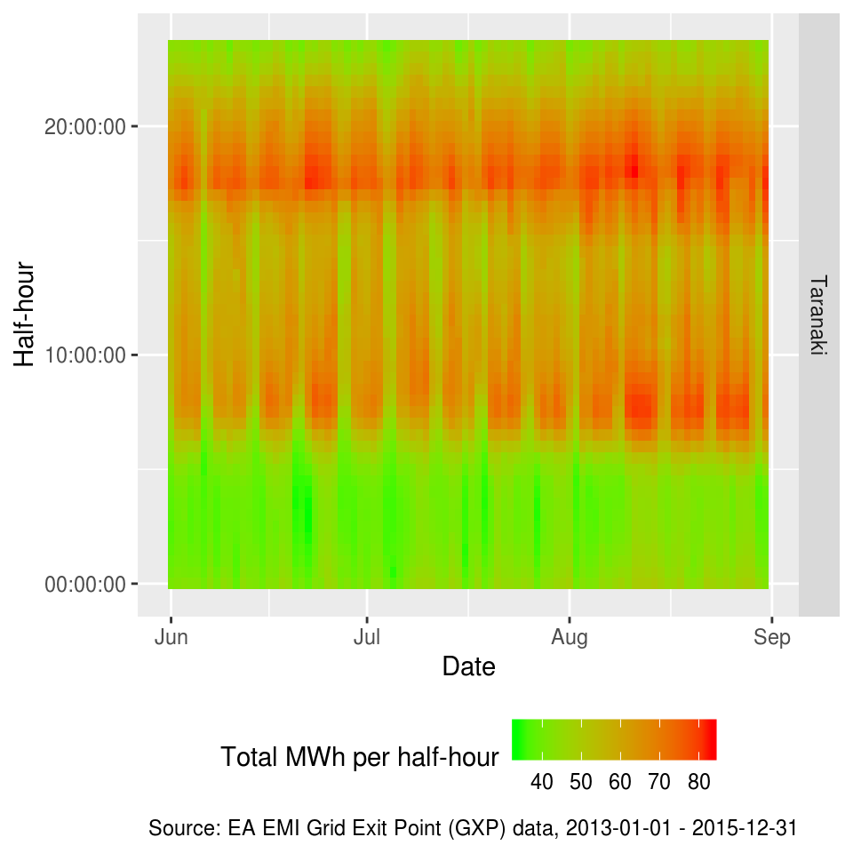

Figure 6.2: Taranaki: Total MWh per half hour

Table 6.3 shows the top 10 peak demand periods.

Table 6.3: Top 10 of top 100 Taranaki peak demand half-hours

| regionName | Time_Period | hms | rDateTime | weekdays | peakPeriod | sumkWh |
| --- | --- | --- | --- | --- | --- | --- |
| Taranaki | TP37 | 18:00:00 | 2015-08-11 18:00:00 | Weekdays | Evening peak | 83244 |
| Taranaki | TP38 | 18:30:00 | 2015-08-11 18:30:00 | Weekdays | Evening peak | 82281 |
| Taranaki | TP37 | 18:00:00 | 2015-08-10 18:00:00 | Weekdays | Evening peak | 81820 |
| Taranaki | TP37 | 18:00:00 | 2015-08-18 18:00:00 | Weekdays | Evening peak | 81664 |
| Taranaki | TP36 | 17:30:00 | 2015-08-18 17:30:00 | Weekdays | Evening peak | 81582 |
| Taranaki | TP36 | 17:30:00 | 2015-06-22 17:30:00 | Weekdays | Evening peak | 81563 |
| Taranaki | TP36 | 17:30:00 | 2015-08-31 17:30:00 | Weekdays | Evening peak | 81461 |
| Taranaki | TP36 | 17:30:00 | 2015-08-24 17:30:00 | Weekdays | Evening peak | 80993 |
| Taranaki | TP36 | 17:30:00 | 2015-06-23 17:30:00 | Weekdays | Evening peak | 80841 |
| Taranaki | TP37 | 18:00:00 | 2015-08-24 18:00:00 | Weekdays | Evening peak | 80661 |

Table 6.4 shows when the 100 peak demand periods occured.

Table 6.4: Taranaki peak demand half-hours

| Time_Period | hms | weekdays | peakPeriod | nHalfHours |
| --- | --- | --- | --- | --- |
| TP37 | 18:00:00 | Weekdays | Evening peak | 26 |
| TP36 | 17:30:00 | Weekdays | Evening peak | 24 |
| TP38 | 18:30:00 | Weekdays | Evening peak | 12 |
| TP16 | 07:30:00 | Weekdays | Morning peak | 11 |
| TP17 | 08:00:00 | Weekdays | Morning peak | 9 |
| TP34 | 16:30:00 | Weekdays | Day time | 5 |
| TP15 | 07:00:00 | Weekdays | Morning peak | 3 |
| TP35 | 17:00:00 | Weekdays | Evening peak | 3 |
| TP18 | 08:30:00 | Weekdays | Morning peak | 2 |
| TP37 | 18:00:00 | Weekends | Evening peak | 2 |
| TP39 | 19:00:00 | Weekdays | Evening peak | 2 |
| TP40 | 19:30:00 | Weekdays | Evening peak | 1 |

# 7 Summary

This report used the EA EMI GXP data to:

- identify the ‘peak’ demand half hours in the two regions under study.

This report described the results of this work and directed the reader to relevant R code where necessary.

All code used to create this report is available from:

- https://github.com/CfSOtago/GREENGridEECA

The archived and most recent version of the report is available from:

- https://cfsotago.github.io/GREENGridEECA/

The selected half-hours can be found in the [github repo](https://cfsotago.github.io/GREENGridEECA/data/).

# 8 Data Annex

## 8.1 GXP summary

Descriptive statistics for original EA GXP data:

```
## Skim summary statistics
##  n obs: 8511095
##  n variables: 38
##
## ── Variable type:character ───────────────────────────────────────────────────────────────────────────────────────────────────────────────────────────
##         variable missing complete       n min max empty n_unique
##      description  205843  8305252 8511095   4  20     0      167
##   FLOW_DIRECTION       0  8511095 8511095   1   1     0        1
##  GENERATION_TYPE       0  8511095 8511095   2   2     0        3
##         GlobalID  205843  8305252 8511095  36  36     0      167
##       MXLOCATION       0  8511095 8511095   3   3     0      176
##             node       0  8511095 8511095   7   7     0      239
##         NWK_Code       0  8511095 8511095   4   4     0       57
##            rDate       0  8511095 8511095  10  10     0      730
##           region 8125721   385374 8511095   1   1     0        2
##      region name 8125721   385374 8511095   8  11     0        2
##       regionName 8125721   385374 8511095   8  11     0        2
##           status  205843  8305252 8511095  12  12     0        1
##           STATUS       0  8511095 8511095   1   5     0        3
##          strTime       0  8511095 8511095   7   8     0       49
##                t       0  8511095 8511095   1   1     0        1
##      Time_Period       0  8511095 8511095   3   4     0       49
##           TRADER       0  8511095 8511095   4   4     0        9
##     TRADING_DATE       0  8511095 8511095  10  10     0      730
##             type  205843  8305252 8511095   3   5     0        3
##     UNIT_MEASURE       0  8511095 8511095   3   3     0        1
##         weekdays       0  8511095 8511095   8   8     0        2
##
## ── Variable type:Date ────────────────────────────────────────────────────────────────────────────────────────────────────────────────────────────────
##  variable missing complete       n        min        max     median
##      date       0  8511095 8511095 2013-01-01 2015-12-31 2013-12-26
##  n_unique
##       730
##
## ── Variable type:difftime ────────────────────────────────────────────────────────────────────────────────────────────────────────────────────────────
##  variable missing complete       n    min        max   median n_unique
##  halfHour       0  8511095 8511095 0 secs 84600 secs 11:30:00       48
##       hms       0  8511095 8511095 0 secs 84600 secs 11:30:00       48
##
## ── Variable type:factor ──────────────────────────────────────────────────────────────────────────────────────────────────────────────────────────────
```

[output cut: 27 more lines]

```
##         X  205843  8305252 8511095 1680430.91  2e+05    1153139 1504449
##         Y  205843  8305252 8511095 5514957.07 327759.44 4830103 5209968
##      year       0  8511095 8511095    2013.99      1       2013    2013
##      p50     p75    p100     hist
##     2967   10767  292945 ▇▁▁▁▁▁▁▁
##        7      10      12 ▇▅▇▃▅▇▅▇
##  1753729 1831847   2e+06 ▁▂▃▂▂▇▇▃
##  5619536 5779107 6082717 ▂▃▃▃▂▆▇▁
##     2013    2015    2015 ▇▁▁▁▁▁▁▇
##
## ── Variable type:POSIXct ─────────────────────────────────────────────────────────────────────────────────────────────────────────────────────────────
##   variable missing complete       n        min        max     median
##  rDateTime       0  8511095 8511095 2013-01-01 2015-12-31 2013-12-26
##  n_unique
##     35032
```

# 9 Runtime

Analysis completed in 193.44 seconds ( 3.22 minutes) using knitr in [RStudio](http://www.rstudio.com) with R version 3.4.4 (2018-03-15) running on x86_64-pc-linux-gnu.

# 10 R environment

## 10.1 R packages used

- base R (R Core Team 2016)
- bookdown (Xie 2016a)
- data.table (Dowle et al. 2015)
- ggplot2 (Wickham 2009)
- kableExtra (Zhu 2018)
- knitr (Xie 2016b)
- lubridate (Grolemund and Wickham 2011)
- rmarkdown (Allaire et al. 2018)

# References

Allaire, JJ, Yihui Xie, Jonathan McPherson, Javier Luraschi, Kevin Ushey, Aron Atkins, Hadley Wickham, Joe Cheng, and Winston Chang. 2018. *Rmarkdown: Dynamic Documents for R*. https://CRAN.R-project.org/package=rmarkdown.

Dowle, M, A Srinivasan, T Short, S Lianoglou with contributions from R Saporta, and E Antonyan. 2015. *Data.table: Extension of Data.frame*. https://CRAN.R-project.org/package=data.table.

Grolemund, Garrett, and Hadley Wickham. 2011. “Dates and Times Made Easy with lubridate.” *Journal of Statistical Software* 40 (3): 1–25. http://www.jstatsoft.org/v40/i03/.

R Core Team. 2016. *R: A Language and Environment for Statistical Computing*. Vienna, Austria: R Foundation for Statistical Computing. https://www.R-project.org/.

Wickham, Hadley. 2009. *Ggplot2: Elegant Graphics for Data Analysis*. Springer-Verlag New York. http://ggplot2.org.

Xie, Yihui. 2016a. *Bookdown: Authoring Books and Technical Documents with R Markdown*. Boca Raton, Florida: Chapman; Hall/CRC. https://github.com/rstudio/bookdown.

———. 2016b. *Knitr: A General-Purpose Package for Dynamic Report Generation in R*. https://CRAN.R-project.org/package=knitr.

Zhu, Hao. 2018. *KableExtra: Construct Complex Table with ’Kable’ and Pipe Syntax*. https://CRAN.R-project.org/package=kableExtra.